# The mosaic Package: Helping Students to ‘Think with Data’ Using R

## Additional high-level lattice plots

The *mosaic* package provides several new high-level *lattice* plots, including `bargraph()`, `dotPlot()`, `freqpolygon()`, `ashplot()`, `xqqmath()`, and `plotPoints()`.

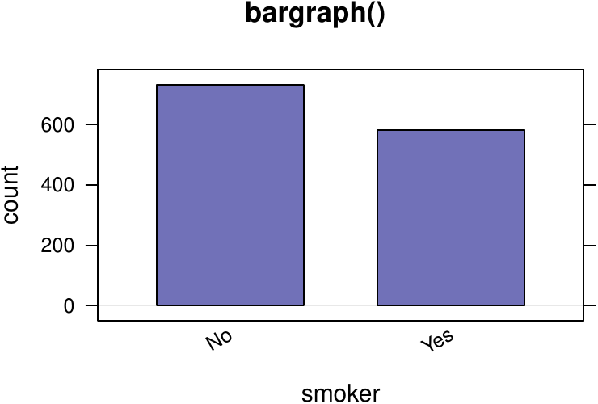

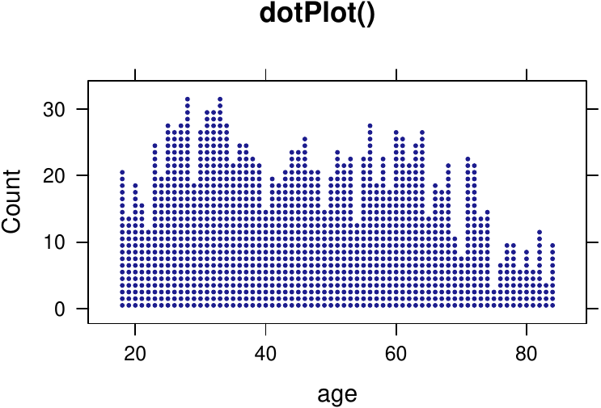

```r
bargraph( ~ smoker, data = Whickham, main = "bargraph()")
dotPlot( ~ age, data = Whickham, width = 1, main = "dotPlot()")
```

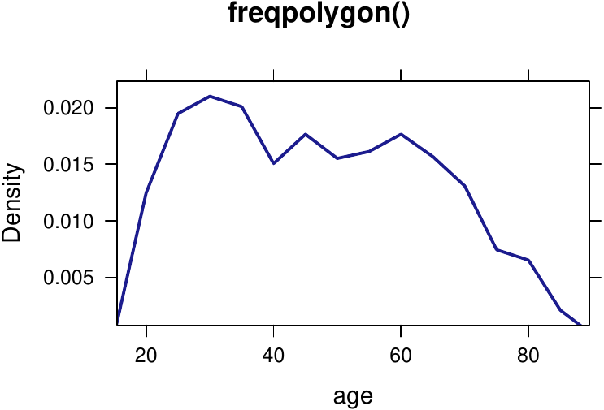

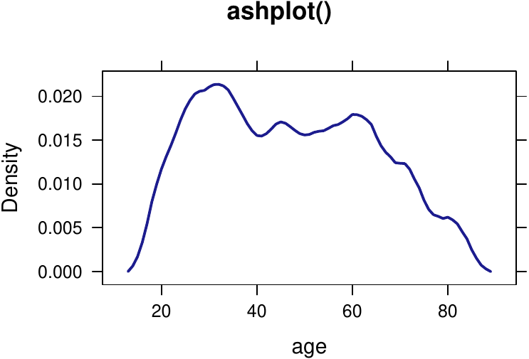

```r
freqpolygon( ~ age, data = Whickham, width = 5, main = "freqpolygon()")
ashplot( ~ age, data = Whickham, width = 5, main = "ashplot()")
```

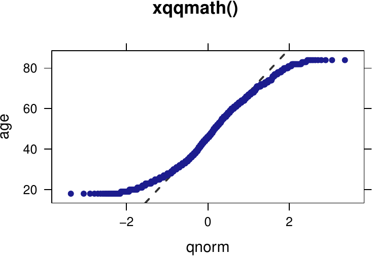

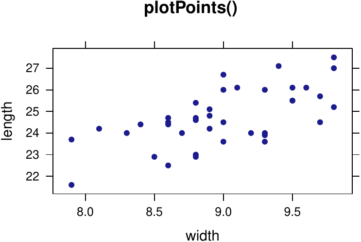

```r
xqqmath( ~ age, data = Whickham, main = "xqqmath()")
plotPoints(length ~ width, data = KidsFeet, main = "plotPoints()")
```

The `bargraph()` function eliminates the need to first summarize the data before constructing a plot with `barplot()` and makes creating these plots from raw data simpler. The dot plots produced by `dotPlot()` are quite different from the Cleveland-style dot plots produced by `dotplot()`. The former are essentially histograms made of stacked dots and can be seen in many introductory statistics texts. They are also useful for producing plots from which students can quickly estimate p-values by counting dots in the tail of a randomization distribution. Frequency polygons and ASH plots (average shifted histograms) are less common, but share many features in common with density plots and are easier to explain to students. The main motivation for `plotPoints()` is the ability to use it to create additional layers on an existing plot with the option `add = TRUE`, otherwise `xyplot()` would suffice.

## Visualizing distributions of random variables

A number of functions make it simple to visualize random variables. The `plotDist()` function creates displays for any distribution for which standard d-, p-, and q- functions exist.

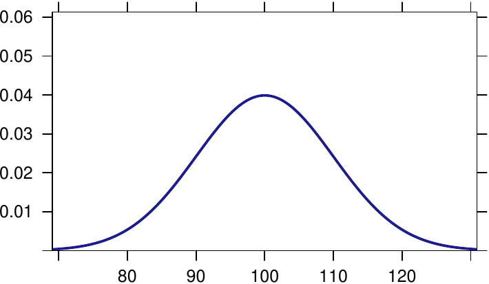

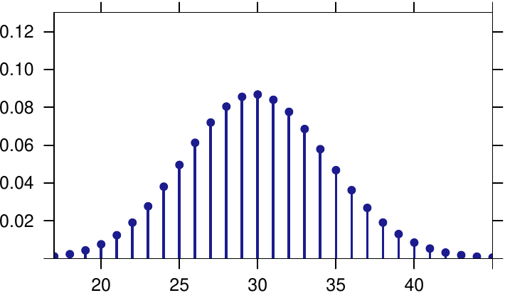

```r
plotDist("norm", mean = 100, sd = 10)
plotDist("binom", size = 100, prob = 0.3)
```

Tail probabilities can be highlighted using the `groups` argument in a way that is analogous to the lattice plots above.

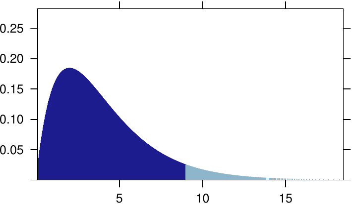

```r
plotDist("chisq", df = 4, groups = x > 9, type = "h")
```

Using the `kind` argument, we can obtain other kinds of plots, including cdfs and probability histograms.

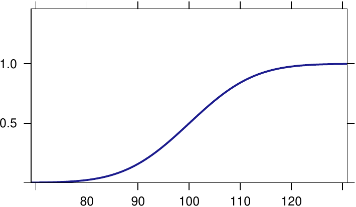

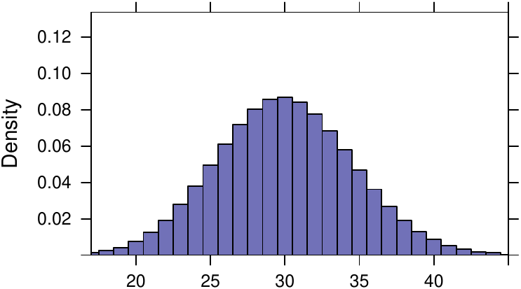

```r
plotDist("norm", mean = 100, sd = 10, kind = "cdf")
plotDist("binom", size = 100, prob = 0.3, kind = "histogram")
```

Any of these plots can be overlaid onto another plot using `add = TRUE`

```r
favstats( ~ age, data = Whickham)
```

```r
##  min Q1 median Q3 max mean   sd    n missing
##   18 32     46 61  84 46.9 17.4 1314       0
```

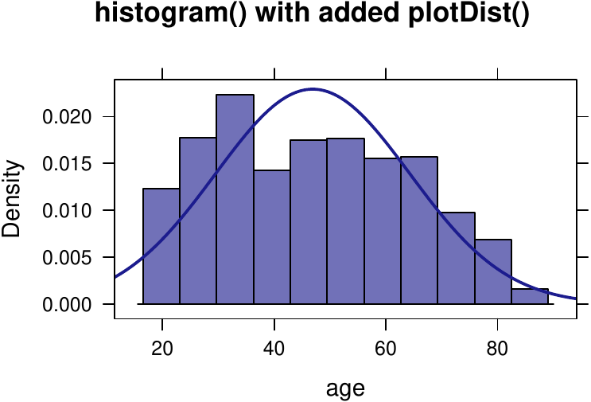

```r
histogram( ~ age, data = Whickham, main = 'histogram() with added plotDist()')
plotDist("norm", params = list(mean = 46.9, sd = 17.4), add = TRUE)
```

or by using additional features of the `histogram()` function provided in the *mosaic* package:

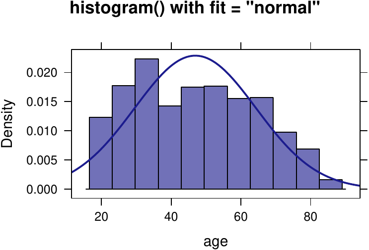

```r
histogram( ~ age, data = Whickham, fit = "normal",
           main = 'histogram() with fit = "normal"')
```

Several other families of distributions can be added to a histogram in a similar way. The `fitdistr()` function from the [*MASS*](https://CRAN.R-project.org/package=MASS) (Venables and Ripley 2002) is used to estimate the parameters of the distribution.

For several distributions, we provide augmented versions of the distribution and quantile functions that assist students in understanding what values are returned by functions like `pnorm()` and `qnorm()`.

```r
xpnorm(-2:2, main = "standard normal")
```

```r
##
## If X ~ N(0, 1), then
##
##  P(X <= -2) = P(Z <= -2) = 0.02275
##      P(X <= -1) = P(Z <= -1) = 0.15866
##      P(X <=  0) = P(Z <=  0) = 0.50000
##      P(X <=  1) = P(Z <=  1) = 0.84134
##      P(X <=  2) = P(Z <=  2) = 0.97725
##  P(X >  -2) = P(Z >  -2) = 0.97725
##      P(X >  -1) = P(Z >  -1) = 0.84134
##      P(X >   0) = P(Z >   0) = 0.50000
##      P(X >   1) = P(Z >   1) = 0.15866
##      P(X >   2) = P(Z >   2) = 0.02275
```

```r
## [1] 0.0228 0.1587 0.5000 0.8413 0.9772
```

```r
xqt(0.975, df = 20, main = "t-distribution with df = 20")
```

```r
##         95%
## 0.000 0.597
```

```r
## [1] 2.09
```

[figure not shown]

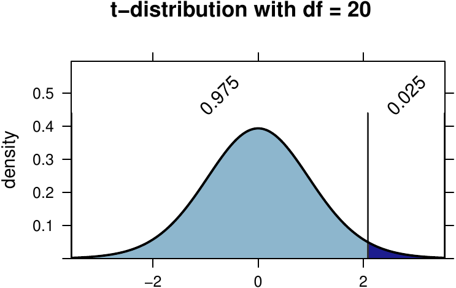

## Basic choropleth maps

The `mUSMap()` and `mWorldMap()` functions provide simple ways to construct choropleth maps of states in the US or countries in the world, and `makeMap()` allows users to provide their own map data.

```r
USArrests <- USArrests %>% mutate(state = row.names(USArrests))
mUSMap(USArrests, key = "state", fill = "UrbanPop")
```

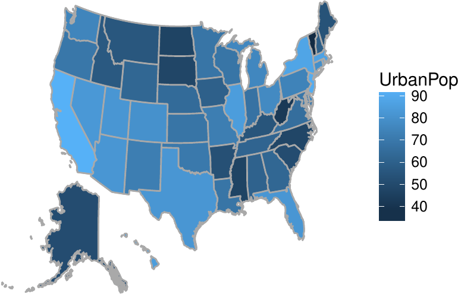

## The `do()` function vs. the `replicate()` function

The usual alternative to `do()` is `replicate()`. For simple situations, `replicate()` can also be easy to use. Each of these stores its results in a vector rather than in a data frame but is otherwise very similar to the corresponding results using `do()`, although the first stores less information.

```r
replicate(3, rflip(20))
```

```r
## [1]  9 13 11
```

```r
replicate(3, diffmean(age ~ smoker, data = resample(Whickham)))
```

```r
## diffmean diffmean diffmean
##    -2.04    -4.56    -5.33
```

Where `do()` really shines is for simulations based on models. The results returned by `do()` are stored in a data frame and include the components of the model most likely to be of interest.

```r
do(3) * lm(shuffle(height) ~ sex + mother, data = Galton)
```

```r
##   Intercept   sexM  mother sigma r.squared      F numdf dendf .row .index
## 1      64.1 0.0356 0.04086  3.59  0.000708 0.3168     2   895    1      1
## 2      66.4 0.0869 0.00543  3.59  0.000156 0.0699     2   895    1      2
## 3      62.2 0.0175 0.07175  3.58  0.002132 0.9562     2   895    1      3
```

Resampling from a linear model performs residual resampling:

```r
Galton.mod <- lm(height ~ sex + mother, data = Galton)
do(3) * lm(height ~ sex + mother, data = resample(Galton.mod))
```

```r
##   Intercept sexM mother sigma r.squared   F numdf dendf .row .index
## 1      41.2 5.01  0.358  2.44     0.534 513     2   895    1      1
## 2      41.1 5.26  0.357  2.40     0.563 577     2   895    1      2
## 3      41.7 5.07  0.351  2.37     0.553 554     2   895    1      3
```

In contrast, `replicate()` returns an object that is inscrutable and unusable for most beginners.

```r
replicate(3, lm(shuffle(height) ~ sex + mother, data = Galton))
```

```r
##               [,1]        [,2]        [,3]
## coefficients  Numeric,3   Numeric,3   Numeric,3
## residuals     Numeric,898 Numeric,898 Numeric,898
## effects       Numeric,898 Numeric,898 Numeric,898
## rank          3           3           3
## fitted.values Numeric,898 Numeric,898 Numeric,898
## assign        Integer,3   Integer,3   Integer,3
## qr            List,5      List,5      List,5
## df.residual   895         895         895
## contrasts     List,1      List,1      List,1
## xlevels       List,1      List,1      List,1
## call          Expression  Expression  Expression
## terms         Expression  Expression  Expression
## model         List,3      List,3      List,3
```

With some additional work, this can be improved somewhat, although less information is being recorded and the matrix should probably be transposed (and perhaps converted to a data frame).

```r
replicate(3, coef(lm(shuffle(height) ~ sex + mother, data = Galton)))
```

```r
##               [,1]    [,2]    [,3]
## (Intercept) 67.774 70.4448 70.2286
## sexM        -0.226  0.0372 -0.0206
## mother      -0.014 -0.0578 -0.0539
```

ASA GAISE College working group, R. Carver, M. Everson, J. Gabrosek, G. H. Rowell, N. J. Horton, R. Lock, et al. 2016. “Guidelines for Assessment and Instruction in Statistics Education: College Report.” http://www.amstat.org/education/gaise.

Baumer, Ben, Mine Cetinkaya-Rundel, Andrew Bray, Linda Loi, and Nicholas J Horton. 2014. “R Markdown: Integrating a Reproducible Analysis Tool into Introductory Statistics.” *Technology Innovations in Statistics Education* 8 (1). http://escholarship.org/uc/item/90b2f5xh.

De Veaux, R. D., P. F. Velleman, and D. E. Bock. 2014. *Intro Stats*. Always Learning. Pearson Education, Limited. https://books.google.com/books?id=3mhRnwEACAAJ.

———. 2015. *Stats: Data and Models*. Pearson Education. https://books.google.com/books?id=0degBwAAQBAJ.

Grolemund, Garrett, and Hadley Wickham. 2014. “A Cognitive Interpretation of Data Analysis.” *International Statistical Review* 82 (2): 184–204. http://EconPapers.repec.org/RePEc:bla:istatr:v:82:y:2014:i:2:p:184-204.

Hesterberg, Tim C. 2015. “What Teachers Should Know about the Bootstrap: Resampling in the Undergraduate Statistics Curriculum.” *The American Statistician* 69 (4): 371–86. http://www.ncbi.nlm.nih.gov/pmc/articles/PMC4784504.

Horton, Nicholas J., Benjamin S. Baumer, and Hadley Wickham. 2015. “Setting the Stage for Data Science: Integration of Data Management Skills in Introductory and Second Courses in Statistics.” *CHANCE* 28 (2): 40–50. http://chance.amstat.org/2015/04/setting-the-stage.

Horton, Nicholas J., and Johanna S. Hardin. 2015. “Teaching the Next Generation of Statistics Students to ‘Think with Data’: Special Issue on Statistics and the Undergraduate Curriculum.” *The American Statistician* 69 (4): 259–65. http://amstat.tandfonline.com/doi/full/10.1080/00031305.2015.1094283.

Lock, Robin H., Patti Frazer Lock, Kari Lock Morgan, Eric F. Lock, and Dennis F. Lock. 2013. *Statistics: Unlocking the Power of Data*. John Wiley & Sons.

Moore, D. S., G. P. McCabe, and B. A. Craig. 2014. *Introduction to the Practice of Statistics*. W. H. Freeman. https://books.google.com/books?id=pX1\_AwAAQBAJ.

Nolan, Deborah, and Duncan Temple Lang. 2010. “Computing in the Statistics Curricula.” *The American Statistician* 64 (2): 97–107. http://dx.doi.org/10.1198/tast.2010.09132.

Pruim, Randall. 2011. “Teaching Statistics with R.” In *Joint Statistics Meetings Roundtable*.

Pruim, Randall, Nicholas J. Horton, and Daniel T. Kaplan. 2016. “Resources Related to the Mosaic Package.” Project MOSAIC. https://cran.r-project.org/web/packages/mosaic/vignettes/mosaic-resources.html.

Pruim, Randall, Daniel T. Kaplan, and Nicholas J. Horton. 2016. *Mosaic: Project MOSAIC Statistics and Mathematics Teaching Utilities*. https://github.com/ProjectMOSAIC/mosaic.

———. n.d. *mosaicData: Project MOSAIC (Mosaic-Web.org) Data Sets*. https://github.com/ProjectMOSAIC/mosaicData.

Ramsey, Fred, and Dan Schafer. 2013. *Statistical Sleuth: A Course in Methods of Data Analysis*. Brooks-Cole.

Ridgway, J. 2016. “Implications of the Data Revolution for Statistics Education.” *International Statistical Review* 84 (3): 327–557.

Salsburg, David. 2002. *The Lady Tasting Tea: How Statistics Revolutionized Science in the Twentieth Century*. Paperback; Holt Paperbacks.

Sarkar, Deepayan. 2008. *Lattice: Multivariate Data Visualization with r*. New York: Springer-Verlag. http://lmdvr.r-forge.r-project.org.

Stoudt, S, Y Cao, D. Udwin, and N. J. Horton. 2014. “What Percent of the Continental US Is Within One Mile of a Road?” *Statistics Education Web*. http://www.amstat.org/education/STEW/pdfs/PercentWithinMileofRoad.pdf.

Tintle, Nathan, Beth L. Chance, George W. Cobb, Allan J. Rossman, Soma Roy, Todd Swanson, and Jill VanderStoep. 2016. *Introduction to Statistical Investigations*. John Wiley & Sons.

Tintle, N., B. Chance, G. W. Cobb, S. Roy, T. Swanson, and J. VanderStoep. 2015. “Combating Anti-Statistical Thinking Using Simulation-Based Methods throughout the Undergraduate Curriculum.” *The American Statistician* 69 (4): 362–70. https://doi.org/10.1080/00031305.2015.1081619.

Venables, W. N., and B. D. Ripley. 2002. *Modern Applied Statistics with s*. 4th ed. New York: Springer-Verlag. http://www.stats.ox.ac.uk/pub/MASS4.

Wang, Xiaofei, Cynthia Rush, and Nicholas J. Horton. 2017. “Data Visualization on Day One: Bringing Big Ideas into Intro Stats Early and Often.” *Technology Innovations in Statistics Education* in press. https://arxiv.org/abs/1705.08544.

Wickham, Hadley. 2009. *Ggplot2: Elegant Graphics for Data Analysis*. Springer-Verlag. http://had.co.nz/ggplot2/book.

Wickham, Hadley, and Romain Francois. 2015. *Dplyr: A Grammar of Data Manipulation*. https://github.com/hadley/dplyr.

Wild, C J, M Pfannkuch, M Regan, and N J Horton. 2011. “Towards More Accessible Conceptions of Statistical Inference.” *Journal of the Royal Statistical Society A* 174 (part 2): 247–95.